# Equipo 4

18/1/2023

[figure not shown]

## Equipo conformado por:

- Deister Navarro Derek
- Dimas Ramirez Luis Daniel
- Hernandez Molina Marlene Zoobeida
- Hernandez Silva Hatziri
- Krauss Guzman Alexis
- Ortiz Vega Miroslava Guadalupe

Este conjunto de datos proporciona datos desde el 1 de enero de 2013 hasta el 24 de abril de 2017 en la ciudad de Delhi, India.

La **variables** son :la temperatura media, la humedad, la presión media.

| Variable |  |  |
| --- | --- | --- |
| Temperatura media. | Promediada a partir de múltiples intervalos de 3 horas en un día. | Variable dependiente |
| Humedad | Gramos de vapor de agua por metro cúbico de volumen de aire | Variable explicativa. |
| Presión media | Medida en atm(atmósfera estándar) | Variable explicativa. |
| Velocidad del viento | KM/H | Variable explicativa. |

```r
library(readr)
library(readxl)
data <- read_csv("DailyDelhiClimateTrain.csv")
f=data.frame(data)

DT::datatable(f, editable = 'cell-border stripe')
```

|  | date | meantemp | humidity | wind_speed | meanpressure |
| --- | --- | --- | --- | --- | --- |
| 1 | 2013-01-01 | 10 | 84.5 | 0 | 1015.66666666667 |
| 2 | 2013-01-02 | 7.4 | 92 | 2.98 | 1017.8 |
| 3 | 2013-01-03 | 7.16666666666667 | 87 | 4.63333333333333 | 1018.66666666667 |
| 4 | 2013-01-04 | 8.66666666666667 | 71.3333333333333 | 1.23333333333333 | 1017.16666666667 |
| 5 | 2013-01-05 | 6 | 86.8333333333333 | 3.7 | 1016.5 |
| 6 | 2013-01-06 | 7 | 82.8 | 1.48 | 1018 |
| 7 | 2013-01-07 | 7 | 78.6 | 6.3 | 1020 |
| 8 | 2013-01-08 | 8.85714285714286 | 63.7142857142857 | 7.14285714285714 | 1018.71428571429 |
| 9 | 2013-01-09 | 14 | 51.25 | 12.5 | 1017 |
| 10 | 2013-01-10 | 11 | 62 | 7.4 | 1015.66666666667 |

[output cut: 1452 more lines]

# Modelos lineales

## Modelo LIN-LIN

```r
modelo_linlin <- lm( data$meantemp~ data$humidity + data$meanpressure + data$wind_speed)
modelo_linlin
```

```
##
## Call:
## lm(formula = data$meantemp ~ data$humidity + data$meanpressure +
##     data$wind_speed)
##
## Coefficients:
##       (Intercept)      data$humidity  data$meanpressure    data$wind_speed
##         39.961734          -0.233089          -0.001455           0.172033
```

```r
summary(modelo_linlin)
```

```
##
## Call:
## lm(formula = data$meantemp ~ data$humidity + data$meanpressure +
##     data$wind_speed)
##
## Residuals:
##      Min       1Q   Median       3Q      Max
## -16.0195  -4.7613   0.0676   5.3552  12.5069
##
## Coefficients:
##                     Estimate Std. Error t value Pr(>|t|)
## (Intercept)       39.9617343  1.1684069  34.202  < 2e-16 ***
## data$humidity     -0.2330892  0.0100648 -23.159  < 2e-16 ***
## data$meanpressure -0.0014550  0.0008687  -1.675   0.0942 .
## data$wind_speed    0.1720329  0.0370087   4.648 3.65e-06 ***
## ---
## Signif. codes:  0 '***' 0.001 '**' 0.01 '*' 0.05 '.' 0.1 ' ' 1
##
## Residual standard error: 5.983 on 1458 degrees of freedom
## Multiple R-squared:  0.3384, Adjusted R-squared:  0.337
## F-statistic: 248.5 on 3 and 1458 DF,  p-value: < 2.2e-16
```

Interpretación:

```r
anova_linlin <- aov(modelo_linlin)
summary(anova_linlin)
```

```
##                     Df Sum Sq Mean Sq F value   Pr(>F)
## data$humidity        1  25806   25806 720.868  < 2e-16 ***
## data$meanpressure    1    113     113   3.153    0.076 .
## data$wind_speed      1    774     774  21.608 3.65e-06 ***
## Residuals         1458  52194      36
## ---
## Signif. codes:  0 '***' 0.001 '**' 0.01 '*' 0.05 '.' 0.1 ' ' 1
```

De la tabla ANOVA podemos observar que que la variable presión es menos significativa estadisticamente. Por lo tanto con una confianza del 92.4% podemos decir que existe suficiente evidencia estadistica para rechazar la hipotesis de que la presion describe el comporamiento de la temperatura.

```r
library(car)
```

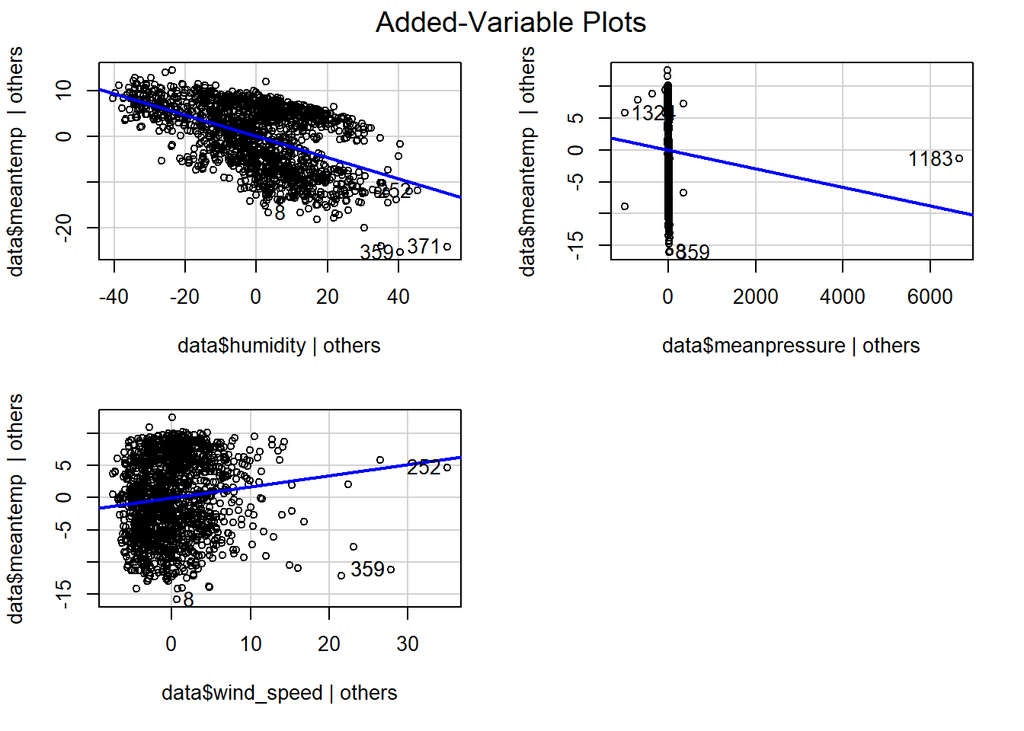

```r
avPlots(modelo_linlin)
```

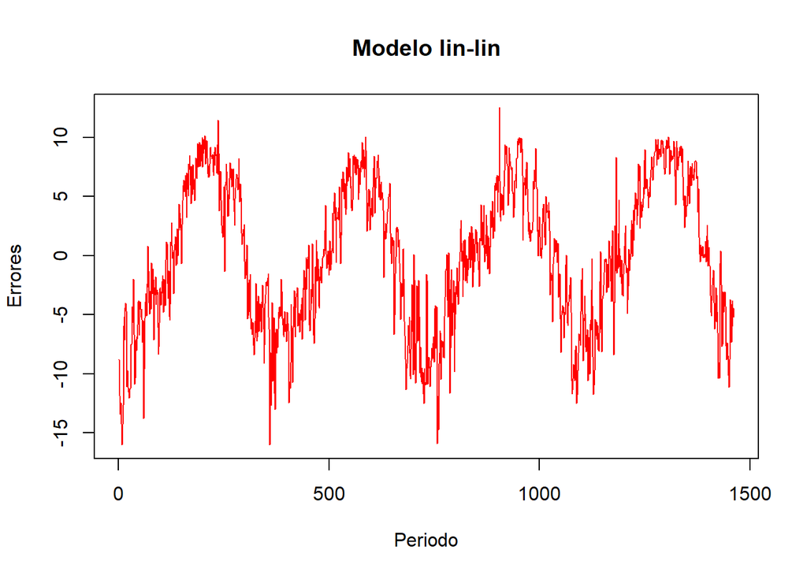

```r
plot(modelo_linlin$residuals, type = "l", col= "red", main="Modelo lin-lin", xlab="Periodo", ylab="Errores")
```

```r
prom <- mean(modelo_linlin$residuals)
```

## Modelo LOG-LOG

Para este caso no utilizamos velocidad del viento porque contiene ceros y al usar la funcion log( ) nos producira un error.

```r
model_loglog <- lm( log(data$meantemp)~ log(data$humidity) + log(data$meanpressure) )
model_loglog
```

```
##
## Call:
## lm(formula = log(data$meantemp) ~ log(data$humidity) + log(data$meanpressure))
##
## Coefficients:
##            (Intercept)      log(data$humidity)  log(data$meanpressure)
##                5.82127                -0.54591                -0.06026
```

```r
exp(model_loglog$coefficients)
```

```
##            (Intercept)     log(data$humidity) log(data$meanpressure)
##            337.4007069              0.5793168              0.9415196
```

```r
summary(model_loglog)
```

```
##
## Call:
## lm(formula = log(data$meantemp) ~ log(data$humidity) + log(data$meanpressure))
##
## Residuals:
##      Min       1Q   Median       3Q      Max
## -1.17535 -0.19734  0.02253  0.25508  0.48165
##
## Coefficients:
##                        Estimate Std. Error t value Pr(>|t|)
## (Intercept)             5.82127    0.39784  14.632   <2e-16 ***
## log(data$humidity)     -0.54591    0.02311 -23.625   <2e-16 ***
## log(data$meanpressure) -0.06026    0.05647  -1.067    0.286
## ---
## Signif. codes:  0 '***' 0.001 '**' 0.01 '*' 0.05 '.' 0.1 ' ' 1
##
## Residual standard error: 0.2853 on 1458 degrees of freedom
##   (1 observation deleted due to missingness)
## Multiple R-squared:  0.2783, Adjusted R-squared:  0.2773
## F-statistic: 281.1 on 2 and 1458 DF,  p-value: < 2.2e-16
```

Interpretación:

En este caso no se utilizo la velocidad del viento debido a que tiene valores nulos los cuales no podemos modelarlos con la funcion de logaritmo.

$r^2$ Ajustado: El 27.73% del comportamiento de nuesrta varialbe dependiente es descrita por el modelo.

```r
anova_loglog <- aov(model_loglog)
summary(anova_loglog)
```

```
##                          Df Sum Sq Mean Sq F value Pr(>F)
## log(data$humidity)        1  45.68   45.68 561.098 <2e-16 ***
## log(data$meanpressure)    1   0.09    0.09   1.139  0.286
## Residuals              1458 118.70    0.08
## ---
## Signif. codes:  0 '***' 0.001 '**' 0.01 '*' 0.05 '.' 0.1 ' ' 1
## 1 observation deleted due to missingness
```

De la tabla anova podemos afirmar que la presión no es estadisticamente significativa par a nuestro modelo

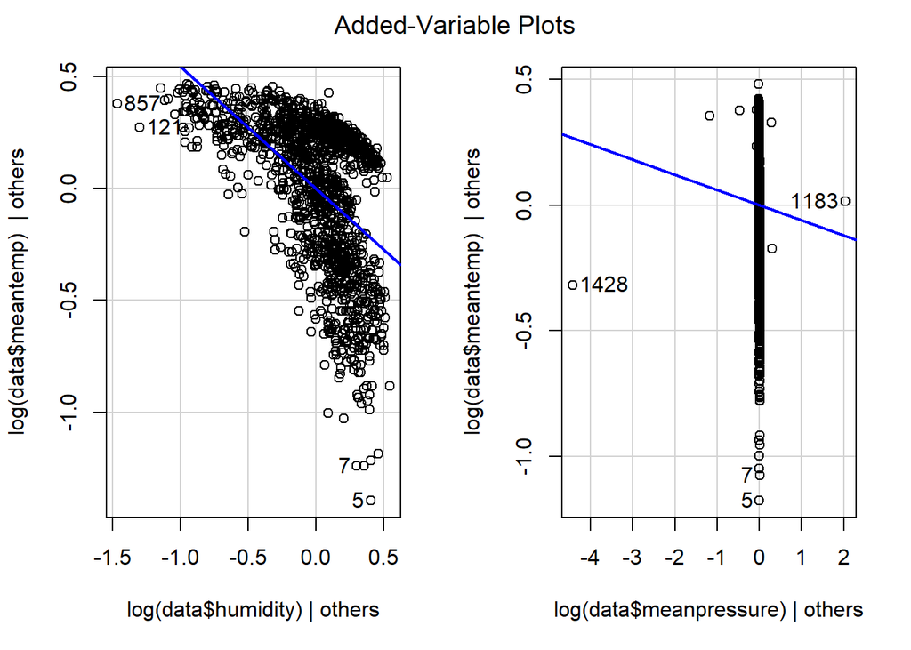

```r
avPlots(model_loglog)
```

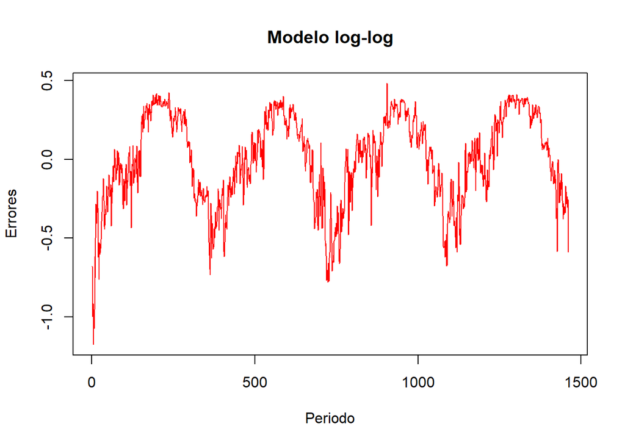

```r
plot(model_loglog$residuals, type = "l", col= "red", main="Modelo log-log", xlab="Periodo", ylab="Errores")
```

```r
prom <- mean(model_loglog$residuals)
```

## Modelo LOG-LIN

```r
model_loglin <- lm( log(data$meantemp)~ data$humidity+ data$meanpressure + data$wind_speed)
model_loglin
```

```
##
## Call:
## lm(formula = log(data$meantemp) ~ data$humidity + data$meanpressure +
##     data$wind_speed)
##
## Coefficients:
##       (Intercept)      data$humidity  data$meanpressure    data$wind_speed
##         3.826e+00         -1.031e-02         -5.843e-05          6.988e-03
```

```r
exp(model_loglin$coefficients)
```

```
##       (Intercept)     data$humidity data$meanpressure   data$wind_speed
##        45.8972588         0.9897390         0.9999416         1.0070122
```

```r
summary(model_loglin)
```

```
##
## Call:
## lm(formula = log(data$meantemp) ~ data$humidity + data$meanpressure +
##     data$wind_speed)
##
## Residuals:
##     Min      1Q  Median      3Q     Max
## -1.1055 -0.1841  0.0233  0.2244  0.5288
##
## Coefficients:
##                     Estimate Std. Error t value Pr(>|t|)
## (Intercept)        3.826e+00  5.440e-02  70.342  < 2e-16 ***
## data$humidity     -1.031e-02  4.686e-04 -22.011  < 2e-16 ***
## data$meanpressure -5.843e-05  4.044e-05  -1.445    0.149
## data$wind_speed    6.988e-03  1.723e-03   4.056 5.27e-05 ***
## ---
## Signif. codes:  0 '***' 0.001 '**' 0.01 '*' 0.05 '.' 0.1 ' ' 1
##
## Residual standard error: 0.2786 on 1458 degrees of freedom
## Multiple R-squared:  0.3124, Adjusted R-squared:  0.311
## F-statistic: 220.8 on 3 and 1458 DF,  p-value: < 2.2e-16
```

Interpretación:

$r^2$ Ajustado: El comportamiendo de la temperatura es descrito en un 31.1% por nuestro modelo.

```r
a_loglin <- aov(model_loglin)
summary(a_loglin)
```

```
##                     Df Sum Sq Mean Sq F value   Pr(>F)
## data$humidity        1  49.95   49.95 643.723  < 2e-16 ***
## data$meanpressure    1   0.18    0.18   2.349    0.126
## data$wind_speed      1   1.28    1.28  16.447 5.27e-05 ***
## Residuals         1458 113.13    0.08
## ---
## Signif. codes:  0 '***' 0.001 '**' 0.01 '*' 0.05 '.' 0.1 ' ' 1
```

En este caso que volvemos a incluir la variable de velocidad del viento, confirmamos nuevamente que esta variable es más significativa que la variable presión.

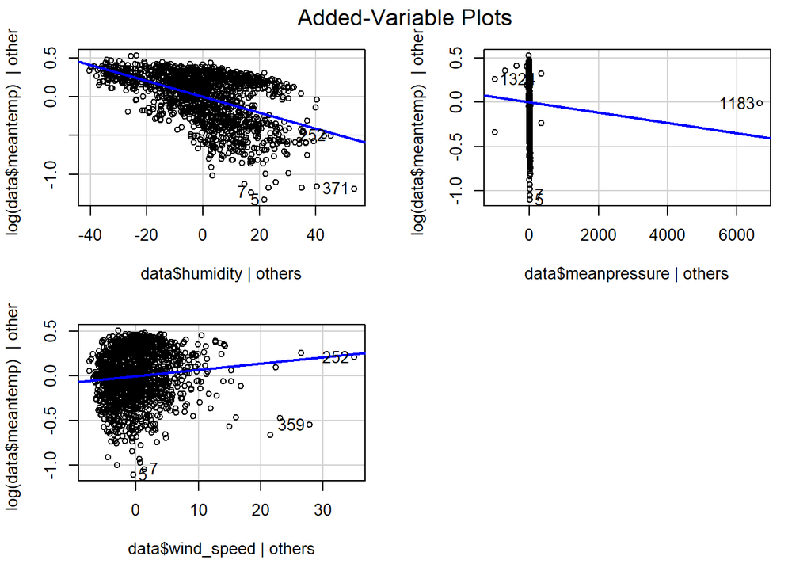

```r
avPlots(model_loglin)
```

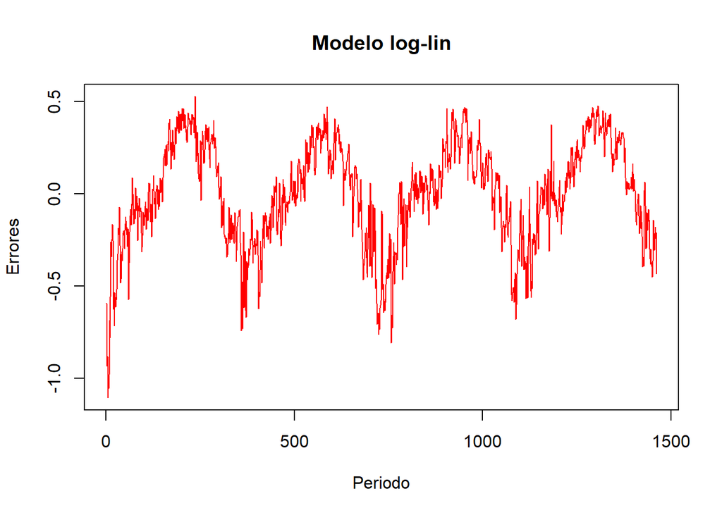

```r
plot(model_loglin$residuals, type = "l", col= "red", main="Modelo log-lin", xlab="Periodo", ylab="Errores")
```

```r
prom <- mean(model_loglin$residuals)
```

## Modelo LIN-LIN

LIN-LIN hasta ahora, teniendo en cuenta la significancia de nuestras variables, el estadistico F, p-values y $r^2$ ajustado; es nuestro mejor modelo.

```r
model_lin_lin1 <- lm( data$meantemp~ data$humidity + data$meanpressure + data$wind_speed)
model_lin_lin1
```

```
##
## Call:
## lm(formula = data$meantemp ~ data$humidity + data$meanpressure +
##     data$wind_speed)
##
## Coefficients:
##       (Intercept)      data$humidity  data$meanpressure    data$wind_speed
##         39.961734          -0.233089          -0.001455           0.172033
```

```r
summary(model_lin_lin1)
```

```
##
## Call:
## lm(formula = data$meantemp ~ data$humidity + data$meanpressure +
##     data$wind_speed)
##
## Residuals:
##      Min       1Q   Median       3Q      Max
## -16.0195  -4.7613   0.0676   5.3552  12.5069
##
## Coefficients:
##                     Estimate Std. Error t value Pr(>|t|)
## (Intercept)       39.9617343  1.1684069  34.202  < 2e-16 ***
## data$humidity     -0.2330892  0.0100648 -23.159  < 2e-16 ***
## data$meanpressure -0.0014550  0.0008687  -1.675   0.0942 .
## data$wind_speed    0.1720329  0.0370087   4.648 3.65e-06 ***
## ---
## Signif. codes:  0 '***' 0.001 '**' 0.01 '*' 0.05 '.' 0.1 ' ' 1
##
## Residual standard error: 5.983 on 1458 degrees of freedom
## Multiple R-squared:  0.3384, Adjusted R-squared:  0.337
## F-statistic: 248.5 on 3 and 1458 DF,  p-value: < 2.2e-16
```

# Transformación

## Transformación a serie de tiempo

```r
library(lubridate)
```

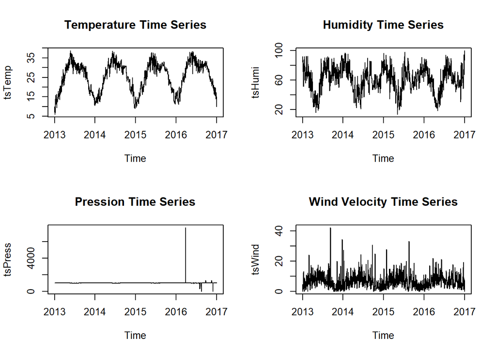

```r
tsTemp<-ts(data$meantemp,start=decimal_date(as.Date("2013-01-01")),frequency=365)
tsHumi<-ts(data$humidity,start=decimal_date(as.Date("2013-01-01")),frequency=365)
tsPress<-ts(data$meanpressure,start=decimal_date(as.Date("2013-01-01")),frequency=365)
tsWind<-ts(data$wind_speed,start=decimal_date(as.Date("2013-01-01")),frequency=365)


par(mfrow=c(2,2))
plot(tsTemp, main= "Temperature Time Series")
plot(tsHumi, main= "Humidity Time Series")
plot(tsPress, main= "Pression Time Series")
plot(tsWind, main= "Wind Velocity Time Series")
```

## Primeras Diferencias

```r
library(forecast)
ndiffs(tsTemp) #Este comando nos dice cuantas diferencias necesita mi serie de tiempo no estacionaria en una serie de tiempo estacionaria
```

```
## [1] 1
```

```r
difTemp<-diff(tsTemp,diff=1,lag=1)   #Dif es para el numero de diferencias que queremos respecto a nuestro dato x
difHumi<-diff(tsHumi,diff=1,lag=1) #H es el numero de rezagos
difPress<-diff(tsPress,diff=1,lag=1)
difWind<-diff(tsWind,diff=1,lag=1)

ndiffs(difTemp) #No se necesita más diferencias proque nuestra serie de tiempo tsTemp ya es estacionaria
```

```
## [1] 0
```

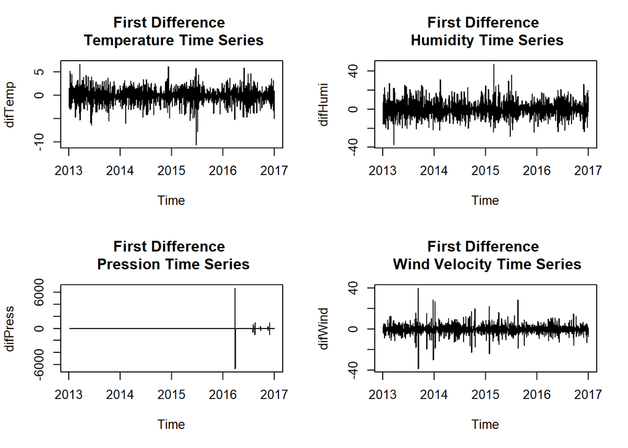

```r
par(mfrow=c(2,2))
plot(difTemp, main= "First Difference \n Temperature Time Series")
plot(difHumi, main= "First Difference \n Humidity Time Series")
plot(difPress, main= "First Difference \n Pression Time Series")
plot(difWind, main= "First Difference \n Wind Velocity Time Series")
```

```r
model_lin_lin_diff<-lm(difTemp~ difHumi+difPress+difWind)
model_lin_lin_diff$coefficients
```

```
##   (Intercept)       difHumi      difPress       difWind
##  1.453850e-03 -1.370359e-01 -5.174102e-05 -2.921508e-02
```

```r
summary(model_lin_lin_diff)
```

```
##
## Call:
## lm(formula = difTemp ~ difHumi + difPress + difWind)
##
## Residuals:
##     Min      1Q  Median      3Q     Max
## -8.0469 -0.6942  0.0906  0.7671  6.3217
##
## Coefficients:
##               Estimate Std. Error t value Pr(>|t|)
## (Intercept)  1.454e-03  3.275e-02   0.044    0.965
## difHumi     -1.370e-01  4.069e-03 -33.679  < 2e-16 ***
## difPress    -5.174e-05  1.287e-04  -0.402    0.688
## difWind     -2.922e-02  6.939e-03  -4.210 2.71e-05 ***
## ---
## Signif. codes:  0 '***' 0.001 '**' 0.01 '*' 0.05 '.' 0.1 ' ' 1
##
## Residual standard error: 1.252 on 1457 degrees of freedom
## Multiple R-squared:  0.4402, Adjusted R-squared:  0.439
## F-statistic: 381.9 on 3 and 1457 DF,  p-value: < 2.2e-16
```

Aunque este modelo de primeras diferencias explica mejor el compartamiento de la temperatura ($r2$ = 43.9%) podemos ver que ni el intercpeto ni la presion son estadisticamente significativos, por lo que nuestro modelo lin lin original sigue siendo mejor.

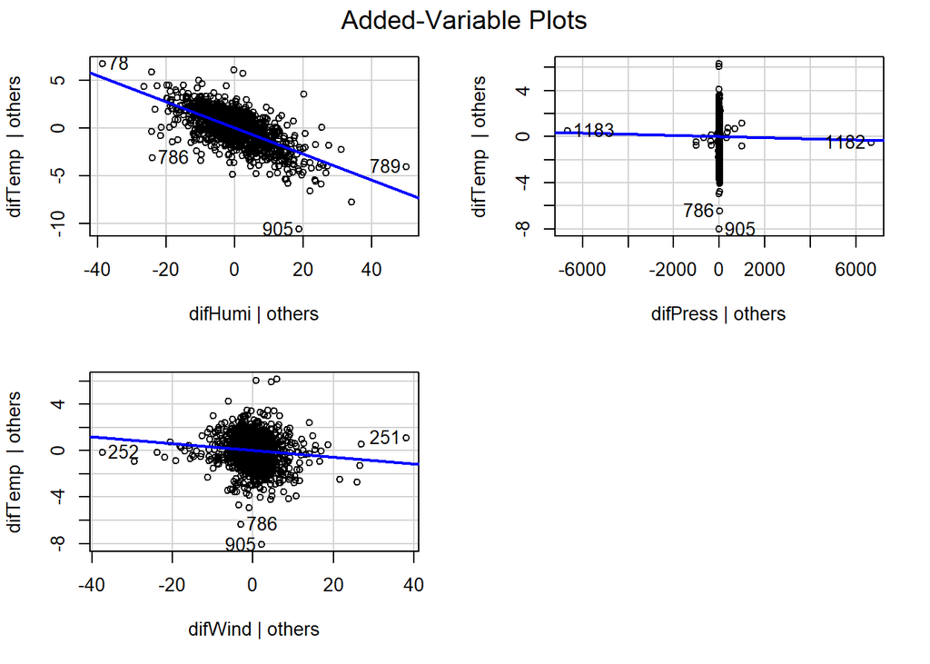

```r
avPlots(model_lin_lin_diff)
```

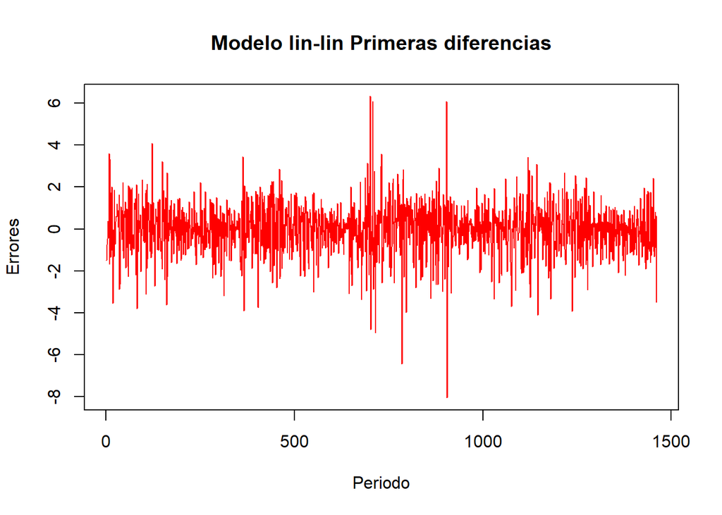

```r
plot(model_lin_lin_diff$residuals, type = "l", col= "red", main="Modelo lin-lin Primeras diferencias", xlab="Periodo", ylab="Errores")
```

No existe autocorrelación porque la media es nula y tiene varianza constante

Comparando los modelos Lin Lin de los datos originales con el modelo que contiene la primera diferencia, notamos que el intercepto del modelo de la diferencia no es estadisticamente significativo ademas de que el error cuadrado ajustado es mayor. Por lo tanto es mejor el modelo LIN LIN de los datos origniales.

## Comparación de errores

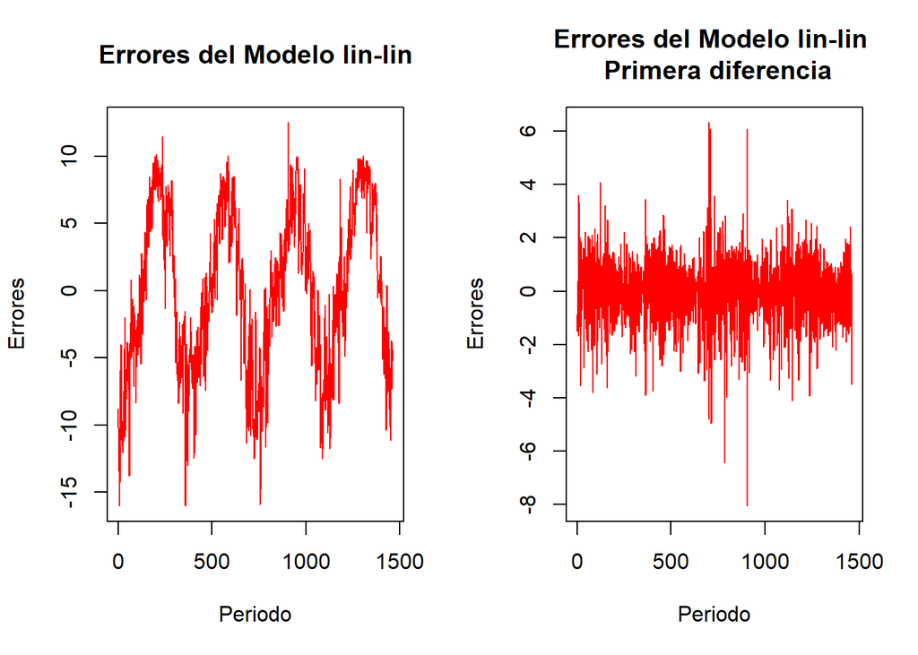

```r
par(mfrow= c(1,2))
plot(model_lin_lin1$residuals, type = "l", col= "red", main="Errores del Modelo lin-lin", xlab="Periodo", ylab="Errores")
plot(model_lin_lin_diff$residuals, type = "l", col= "red", main="Errores del Modelo lin-lin \n Primera diferencia", xlab="Periodo", ylab="Errores")
```

Una vez realizada la primera diferencia para nuestros datos orginiales, observamos que el modelo LIN-LIN genera errores estables

# PRONOSTICOS

El modelo ARMA(p,q) se usa para representar series que son estacionarias sin requerir diferenciancion

Cuando la serie esta diferenciada, se utiliza el modelo ARIMA(p,d,q) donde $d$ es el numero de diferencia. El modelo ARIMA toma en cuenta tendencia pero no componente estacional

El modelo SARIMA(p,d,q)[P,D,Q] toma en cuenta tendencia y tambien componentes estacionales.

Se utilizan las graficas de autocorrelaciones y autocorrelaciones parciales para determinar los valores p,d,q,P,D,Q.

ACF: Nos dice el numero de medias moviles

Partial ACF: Nos dice el numero de autoregresivos.Cuando Solo la primera autocorrelación parcial es estadísticamente no nula porque esta fuera de los limites de confianza; define el valor de p, que es 1. Las autocorrelaciones parciales definen el valor de p cuando se caen abruptamente á cero de un período a otro. En este caso, el valor de p es igual al rezago anterior al que se vuelven nulas

## Autocorrelacion y correlación parcial para nuestra serie de tiempo de Temperatura original

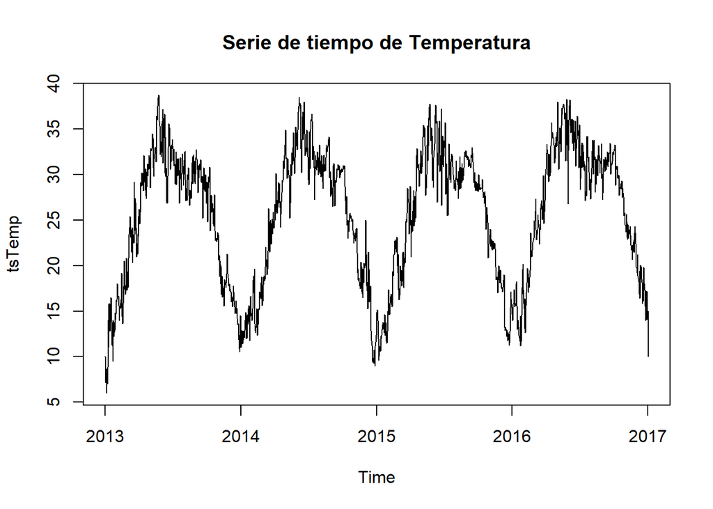

```r
plot(tsTemp , main= "Serie de tiempo de Temperatura")
```

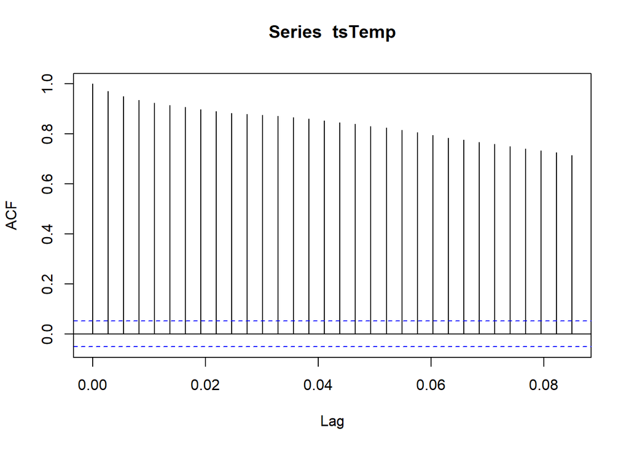

```r
acf(tsTemp, lag.max = NULL, type = c('correlation'), plot = TRUE)
```

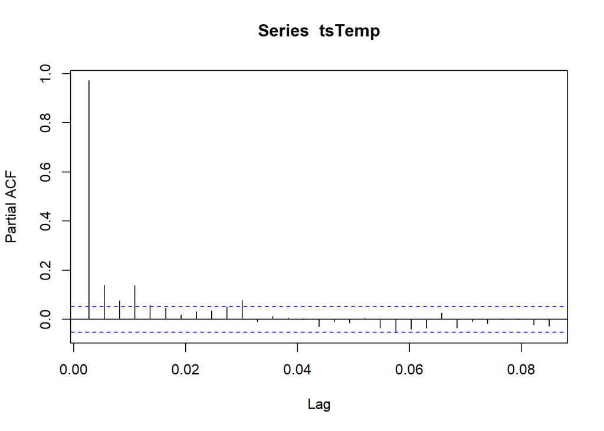

```r
acf(tsTemp, lag.max = NULL, type = c('partial'), plot = TRUE)
```

Para poder hacer pronosticos, necesitamos que nuestra serie de tiempo se esstacionaria.

Para que una serie de tiempo sea estacionaria requerimos que nuestra media (idealmente nula) y varianza sean constantes a lo largo del tiempo y que no haya tendencia en los datos, además de que nuestra gráfica de autocorrelación indique lo mismo.

## Autocorrelacion y correlación parcial para nuestra serie de tiempo diferenciada de Temperatura

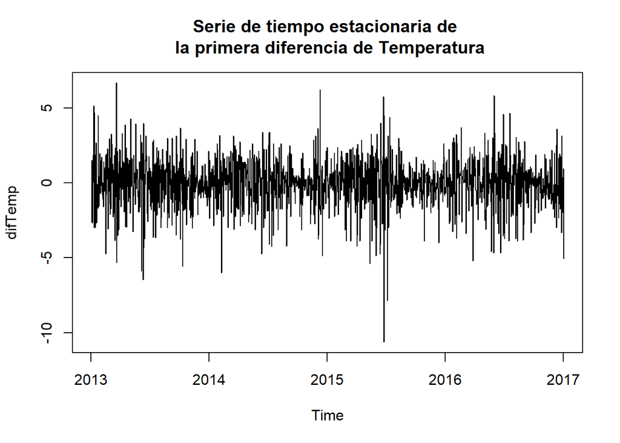

```r
plot(difTemp, main= "Serie de tiempo estacionaria de \n la primera diferencia de Temperatura")
```

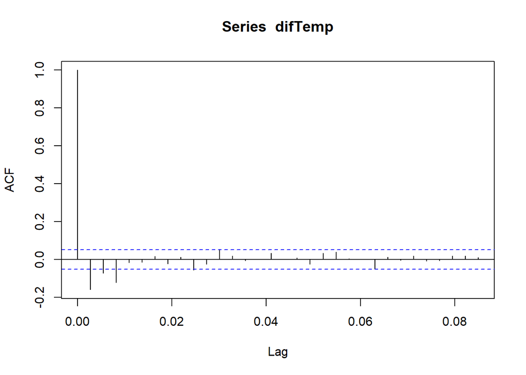

```r
acf(difTemp, lag.max = NULL, type = c('correlation'), plot = TRUE)
```

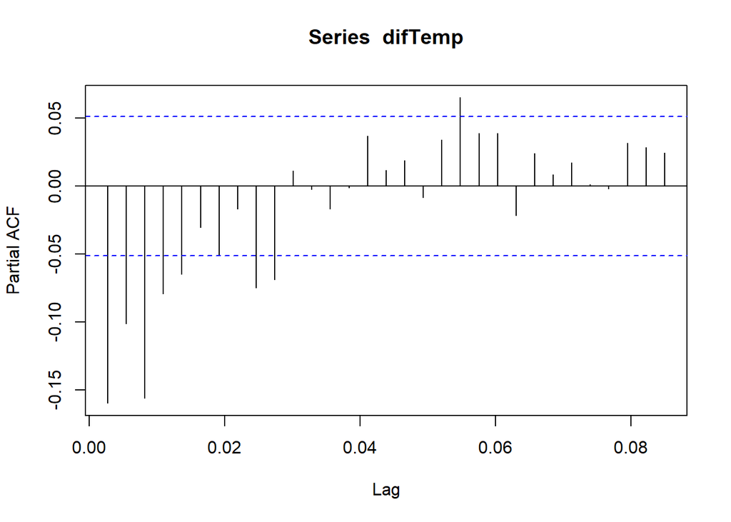

```r
acf(difTemp, lag.max = NULL, type = c('partial'), plot = TRUE)
```

Del grafico de esta serie de tiempo observamos que es estacionaria al tener media nula y varianza constante. Lo logramos al aplicar la primera diferencia de los datos.

## Comparación entre series originales y series diferenciadas

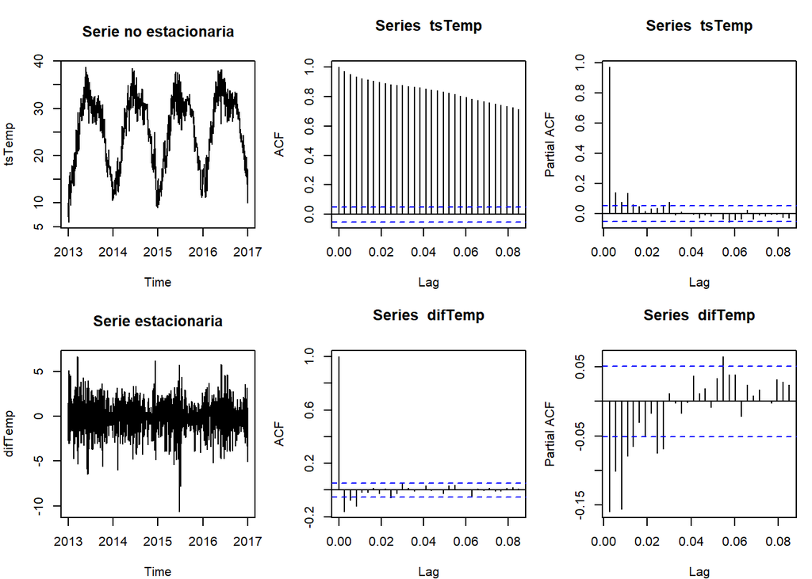

```r
par(mfrow= c(2,3), mar = c(4,4,4,1))
plot(tsTemp, main="Serie no estacionaria")
acf(tsTemp, lag.max = NULL, type = c('correlation'), plot = TRUE)
acf(tsTemp, lag.max = NULL, type = c('partial'), plot = TRUE)

plot(difTemp, main="Serie estacionaria")
acf(difTemp, lag.max = NULL, type = c('correlation'), plot = TRUE)
acf(difTemp, lag.max = NULL, type = c('partial'), plot = TRUE)
```

Con la primera diferencia nuestra serie ya es estacionaria.

## Aplicando el modelo ARIMA para encontrar parametros.

```r
modelo_ARIMA <- auto.arima(data$meantemp,stepwise=FALSE,approximation= FALSE, trace = T, nmodels = 10)
```

```
##
##  ARIMA(0,1,0)                    : 5648.184
##  ARIMA(0,1,0) with drift         : 5650.19
##  ARIMA(0,1,1)                    : 5600.123
##  ARIMA(0,1,1) with drift         : 5602.13
##  ARIMA(0,1,2)                    : 5571.746
##  ARIMA(0,1,2) with drift         : 5573.751
##  ARIMA(0,1,3)                    : 5540.534
##  ARIMA(0,1,3) with drift         : 5542.533
##  ARIMA(0,1,4)                    : 5540.717
##  ARIMA(0,1,4) with drift         : 5542.716
##  ARIMA(0,1,5)                    : 5542.146
##  ARIMA(0,1,5) with drift         : 5544.147
##  ARIMA(1,1,0)                    : 5612.077
##  ARIMA(1,1,0) with drift         : 5614.084
##  ARIMA(1,1,1)                    : 5542.495
##  ARIMA(1,1,1) with drift         : 5544.487
##  ARIMA(1,1,2)                    : 5544.214
##  ARIMA(1,1,2) with drift         : 5546.209
##  ARIMA(1,1,3)                    : 5540.278
##  ARIMA(1,1,3) with drift         : 5542.276
##  ARIMA(1,1,4)                    : 5542.149
##  ARIMA(1,1,4) with drift         : 5544.15
##  ARIMA(2,1,0)                    : 5598.867
##  ARIMA(2,1,0) with drift         : 5600.877
##  ARIMA(2,1,1)                    : 5544.146
##  ARIMA(2,1,1) with drift         : 5546.141
##  ARIMA(2,1,2)                    : 5513.701
##  ARIMA(2,1,2) with drift         : 5515.729
##  ARIMA(2,1,3)                    : 5542.097
##  ARIMA(2,1,3) with drift         : 5544.097
##  ARIMA(3,1,0)                    : 5564.367
##  ARIMA(3,1,0) with drift         : 5566.378
##  ARIMA(3,1,1)                    : 5541.094
##  ARIMA(3,1,1) with drift         : 5543.092
##  ARIMA(3,1,2)                    : 5541.825
##  ARIMA(3,1,2) with drift         : 5543.826
##  ARIMA(4,1,0)                    : 5556.795
##  ARIMA(4,1,0) with drift         : 5558.806
##  ARIMA(4,1,1)                    : 5542.07
##  ARIMA(4,1,1) with drift         : 5544.071
##  ARIMA(5,1,0)                    : 5552.355
##  ARIMA(5,1,0) with drift         : 5554.366
##
##
##
##  Best model: ARIMA(2,1,2)
```

```r
#¿Por que con mi serie de tiempo truena pero con los datos normales no?

summary(modelo_ARIMA)
```

```
## Series: data$meantemp
## ARIMA(2,1,2)
##
## Coefficients:
##          ar1      ar2      ma1     ma2
##       1.6840  -0.6904  -1.9161  0.9225
## s.e.  0.0319   0.0317   0.0180  0.0179
##
## sigma^2 = 2.538:  log likelihood = -2751.83
## AIC=5513.66   AICc=5513.7   BIC=5540.09
##
## Training set error measures:
##                        ME     RMSE      MAE      MPE     MAPE     MASE
## Training set -0.005906605 1.590283 1.194944 -0.30977 5.220815 0.964235
##                     ACF1
## Training set -0.01282475
```

Creando el modelo :

```r
modelo_ar1 <- arima(data$meantemp, order = c(2,1,2), include.mean = FALSE, method = c('CSS-ML'))
modelo_ar1
```

```
##
## Call:
## arima(x = data$meantemp, order = c(2, 1, 2), include.mean = FALSE, method = c("CSS-ML"))
##
## Coefficients:
##          ar1      ar2      ma1     ma2
##       1.6840  -0.6904  -1.9161  0.9225
## s.e.  0.0319   0.0317   0.0180  0.0179
##
## sigma^2 estimated as 2.531:  log likelihood = -2751.83,  aic = 5513.66
```

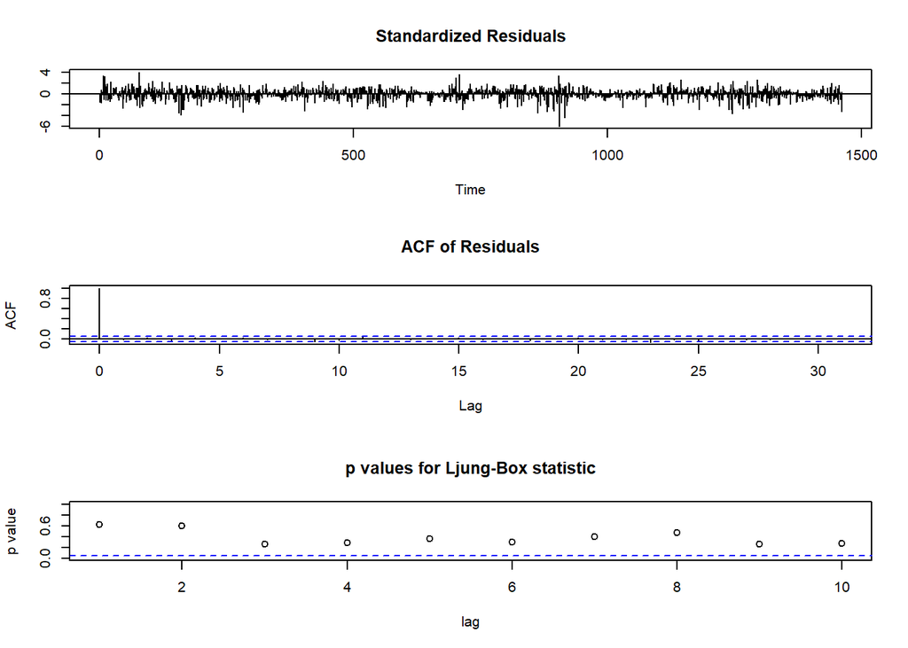

```r
tsdiag(modelo_ar1)
```

Ljung Box: todos los p values son mayores a 0.05 por lo tanto sí hay ruido blanco y nos evidencia que nuestra modelo no es malo y se ajusta bien. Si alguno o todos los p values fueran menores a 0.05 no habria ruido blanco y nuestro modelo no se ajusta bien.

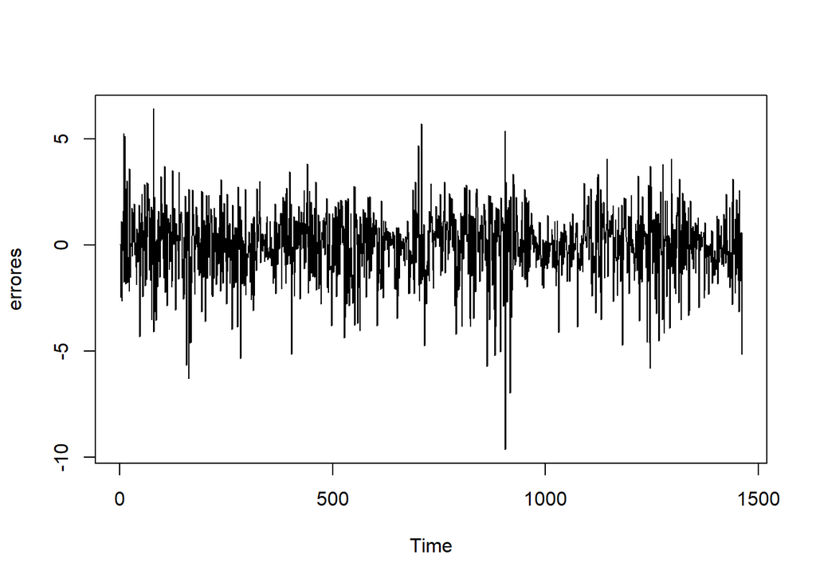

```r
errores <- residuals(modelo_ar1)
plot(errores)
```

## Pronostico

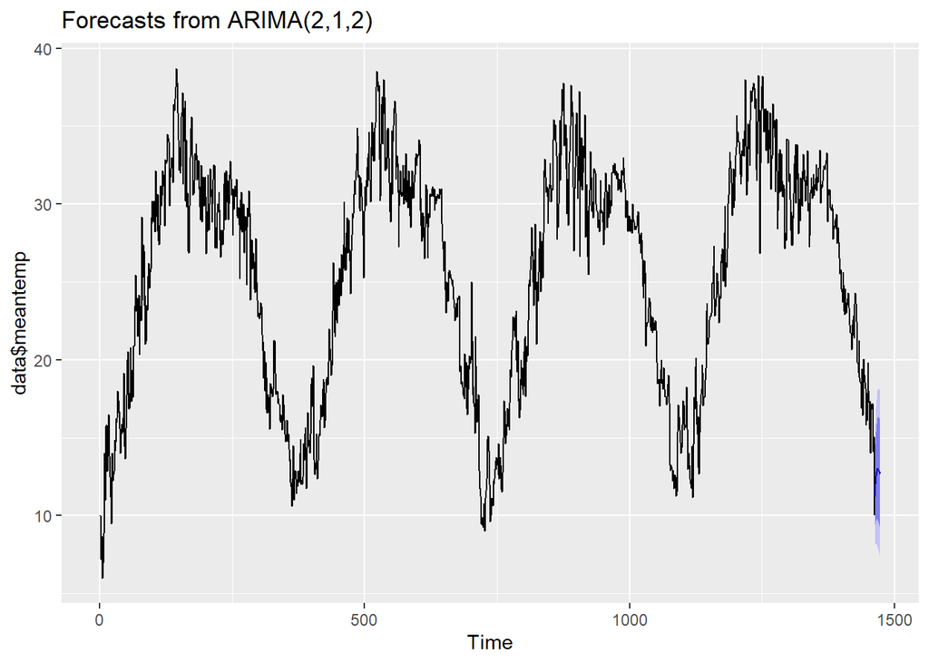

```r
pronostico <- forecast(modelo_ar1, h=10)
autoplot(pronostico)
```

```r
predict(pronostico, h=10)
```

```
##      Point Forecast    Lo 80    Hi 80    Lo 95    Hi 95
## 1463       11.22078 9.182053 13.25951 8.102816 14.33874
## 1464       12.01907 9.448605 14.58953 8.087883 15.95026
## 1465       12.52057 9.665849 15.37530 8.154650 16.88650
## 1466       12.81397 9.781338 15.84660 8.175959 17.45198
## 1467       12.96182 9.804335 16.11930 8.132864 17.79077
## 1468       13.00823 9.754180 16.26228 8.031589 17.98487
## 1469       12.98432 9.649137 16.31950 7.883599 18.08504
## 1470       12.91200 9.503945 16.32006 7.699828 18.12418
## 1471       12.80673 9.329776 16.28369 7.489186 18.12428
## 1472       12.67938 9.134840 16.22393 7.258472 18.10029
```

## Promedio Movil simple con N = 10

```r
library(DescTools)
library(pracma)
library(gridExtra)
library(data.table)
library(smooth)
```

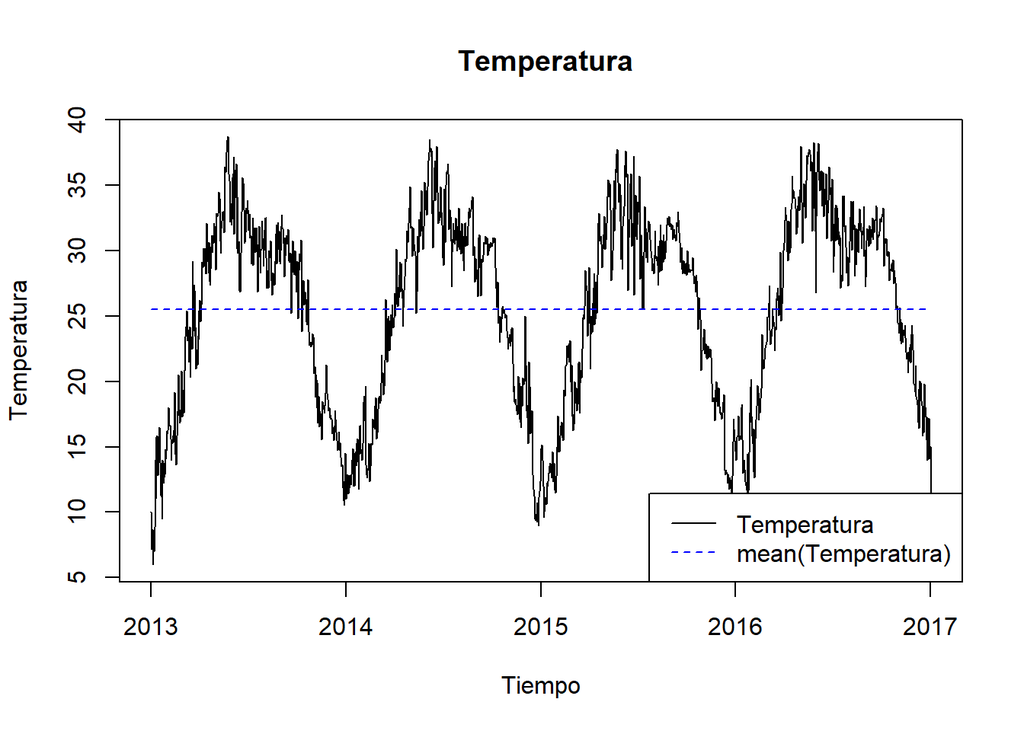

```r
#MAE (y, forecast y)
m <- mean(tsTemp)
ts.plot(tsTemp, m, col= c("black","blue" ), lty = c(1,2), ylab="Temperatura",xlab="Tiempo",main=" Temperatura")
legend("bottomright",c("Temperatura","mean(Temperatura)"),lty=c(1,2),col=c("black","blue" ))
```

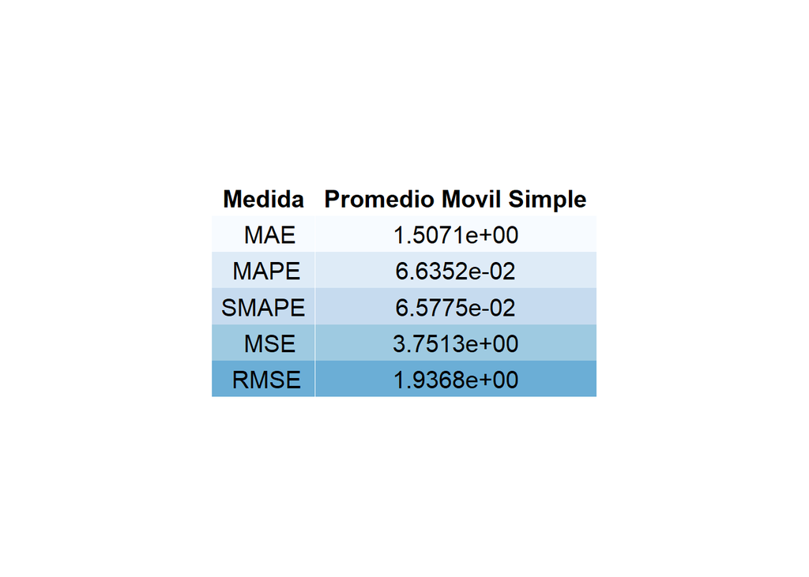

```r
sma <- movavg(tsTemp, 10, type="s")

Prom_simp<-mean(tsTemp)
mae_PromSimp<-MAE(tsTemp, sma)
mape_PromSimp<-MAPE(tsTemp, sma)
smape_PromSimp<-SMAPE(tsTemp, sma)
mse_PromSimp<-MSE(tsTemp, sma)
rmse_PromSimp<-RMSE(tsTemp, sma)
medidas_PromSimp<-matrix(c(mae_PromSimp,mape_PromSimp,smape_PromSimp,mse_PromSimp,rmse_PromSimp))
rownames(medidas_PromSimp)<-c("MAE","MAPE","SMAPE","MSE","RMSE")
colnames(medidas_PromSimp)<-c("Prom Movil Simple")
df_medidas_PromSimp<-as.data.frame(medidas_PromSimp)
tab_medidas_PromSimp<-as.data.table(df_medidas_PromSimp,keep.rownames=TRUE, keep.colnames=FALSE)
colnames(tab_medidas_PromSimp)<-c("Medida","Promedio Movil Simple")
ftab_medidas_PromSimp<-format(tab_medidas_PromSimp, digits=5,scientific=TRUE,big.mark=",",decimal.mark=".",small.mark=",",justify="right")
tem<-ttheme_minimal(base_colour = "black",base_size = 15,core=list(bg_params=list(fill=blues9,col=NA)))
grid.arrange(tableGrob(ftab_medidas_PromSimp,theme=tem))
```

```r
f<-rep(0,40)
for (t in 3:40) f[t]<-(0.75)*tsTemp[t-1]+(0.25)*tsTemp[t-2]
y_ts<-ts(tsTemp[0:40],start=1,frequency = 1)
f_ts<-ts(f,start=1,frequency = 1)
cbind(y_ts,f_ts)
```

```
## Time Series:
## Start = 1
## End = 40
## Frequency = 1
##         y_ts      f_ts
##  1 10.000000  0.000000
##  2  7.400000  0.000000
##  3  7.166667  8.050000
##  4  8.666667  7.225000
##  5  6.000000  8.291667
##  6  7.000000  6.666667
##  7  7.000000  6.750000
##  8  8.857143  7.000000
##  9 14.000000  8.392857
## 10 11.000000 12.714286
```

[output cut: 30 more lines]

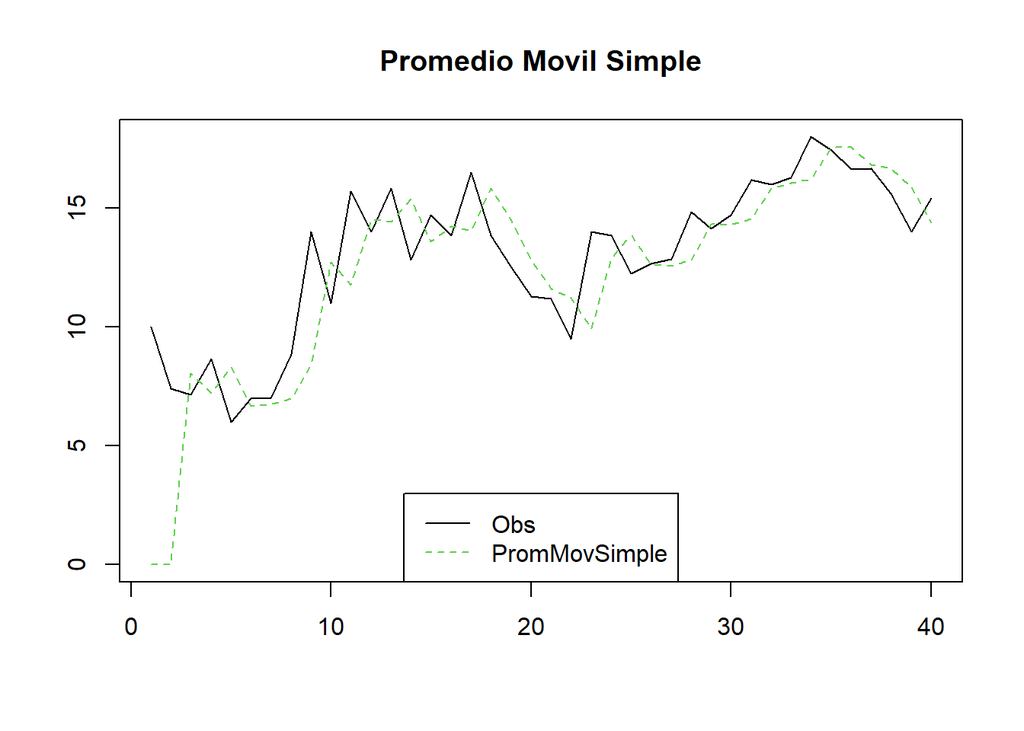

```r
ts.plot(y_ts,f_ts,xlab=NULL,ylab=NULL, main = "Promedio Movil Simple",lty=c(1:2),col=c(1,3))
legend(x="bottom",legend=c("Obs","PromMovSimple"),col=c(1,3),lty=c(1,2))
```

## Promedio movil ponderado W

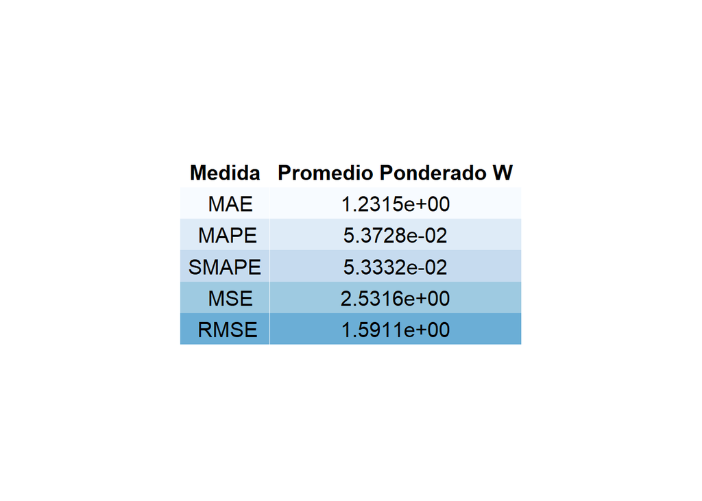

```r
fw <- movavg(tsTemp, 10, type = "w")

mae_PromW<-MAE(tsTemp, fw)
mape_PromW<-MAPE(tsTemp, fw)
smape_PromW<-SMAPE(tsTemp, fw)
mse_PromW<-MSE(tsTemp, fw)
rmse_PromW<-RMSE(tsTemp, fw)
medidas_PromW<-matrix(c(mae_PromW,mape_PromW,smape_PromW,mse_PromW,rmse_PromW))
rownames(medidas_PromW)<-c("MAE","MAPE","SMAPE","MSE","RMSE")
colnames(medidas_PromW)<-c("Ponderada W")
df_medidas_PromW<-as.data.frame(medidas_PromW)
tab_medidas_PromW<-as.data.table(df_medidas_PromW,keep.rownames=TRUE, keep.colnames=FALSE)
colnames(tab_medidas_PromW)<-c("Medida","Promedio Ponderado W")
ftab_medidas_PromW<-format(tab_medidas_PromW, digits=5,scientific=TRUE,big.mark=",",decimal.mark=".",small.mark=",",justify="right")
tem<-ttheme_minimal(base_colour = "black",base_size = 15,core=list(bg_params=list(fill=blues9,col=NA)))
grid.arrange(tableGrob(ftab_medidas_PromW,theme=tem))
```

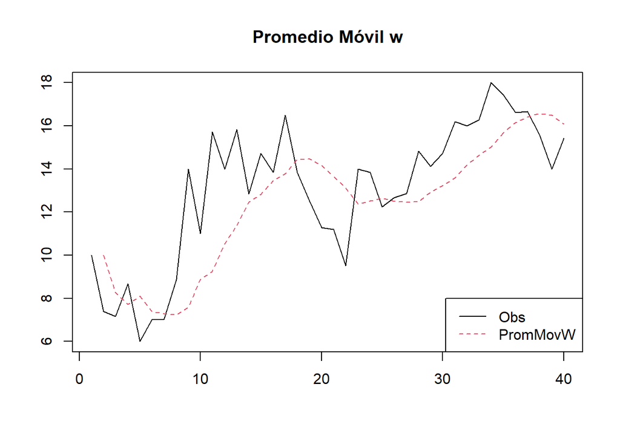

```r
fwt<-rep(0,40)
for(t in 2:40) fwt[t]<-fw[t-1]
for(t in 1) fwt[t]<-NA
fw_ts<-rep(0,19)
fw_ts<-ts(fwt,start=1,frequency=1)
ts.plot(tsTemp[0:40],fw_ts,xlab=NULL,ylab=NULL, main = "Promedio Móvil w",lty=c(1:2),col=c(1,2))
legend(x="bottomright",legend=c("Obs","PromMovW"),col=c(1,2),lty=c(1,2))
```

## Promedio ponderada e

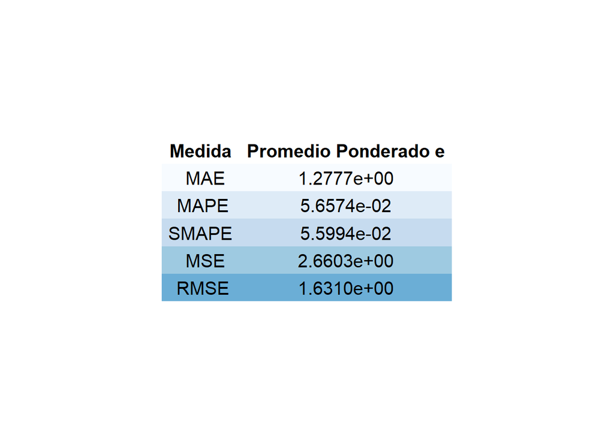

```r
e <- movavg(tsTemp, 10, type = "e")

mae_PromE<-MAE(tsTemp, e)
mape_PromE<-MAPE(tsTemp, e)
smape_PromE<-SMAPE(tsTemp, e)
mse_PromE<-MSE(tsTemp, e)
rmse_PromE<-RMSE(tsTemp, e)
medidas_PromE<-matrix(c(mae_PromE,mape_PromE,smape_PromE,mse_PromE,rmse_PromE))
rownames(medidas_PromE)<-c("MAE","MAPE","SMAPE","MSE","RMSE")
colnames(medidas_PromE)<-c("Ponderada")
df_medidas_PromE<-as.data.frame(medidas_PromE)
tab_medidas_PromE<-as.data.table(df_medidas_PromE,keep.rownames=TRUE, keep.colnames=FALSE)
colnames(tab_medidas_PromE)<-c("Medida","Promedio Ponderado e")
ftab_medidas_PromE<-format(tab_medidas_PromE, digits=5,scientific=TRUE,big.mark=",",decimal.mark=".",small.mark=",",justify="right")
tem<-ttheme_minimal(base_colour = "black",base_size = 15,core=list(bg_params=list(fill=blues9,col=NA)))
grid.arrange(tableGrob(ftab_medidas_PromE,theme=tem))
```

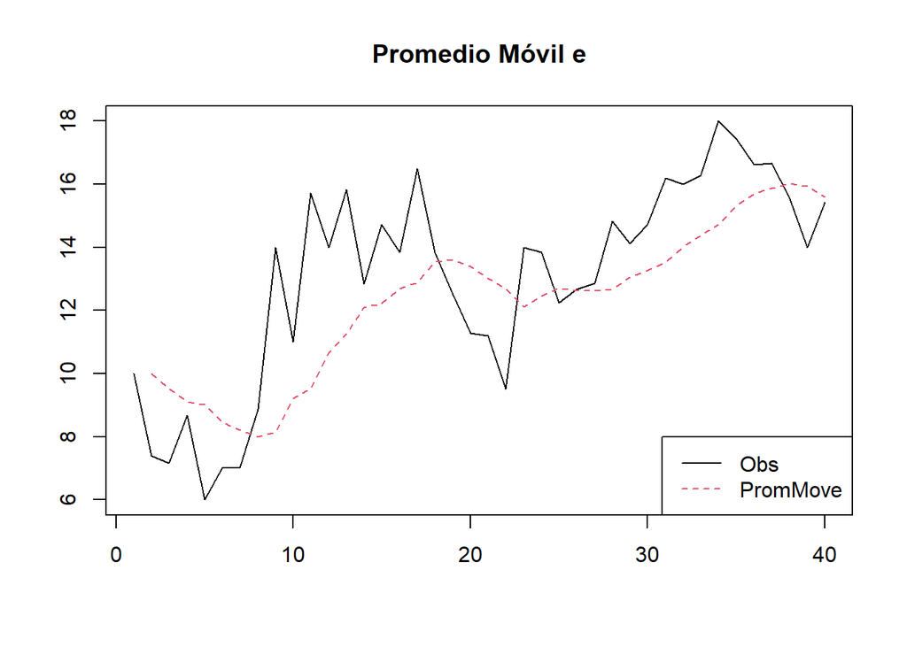

```r
fwt<-rep(0,40)
for(t in 2:40) fwt[t]<-e[t-1]
for(t in 1) fwt[t]<-NA
fw_ts<-rep(0,19)
fw_ts<-ts(fwt,start=1,frequency=1)
ts.plot(tsTemp[0:40],fw_ts,xlab=NULL,ylab=NULL, main = "Promedio Móvil e",lty=c(1:2),col=c(1,2))
legend(x="bottomright",legend=c("Obs","PromMove"),col=c(1,2),lty=c(1,2))
```

## Promedio exponencial r

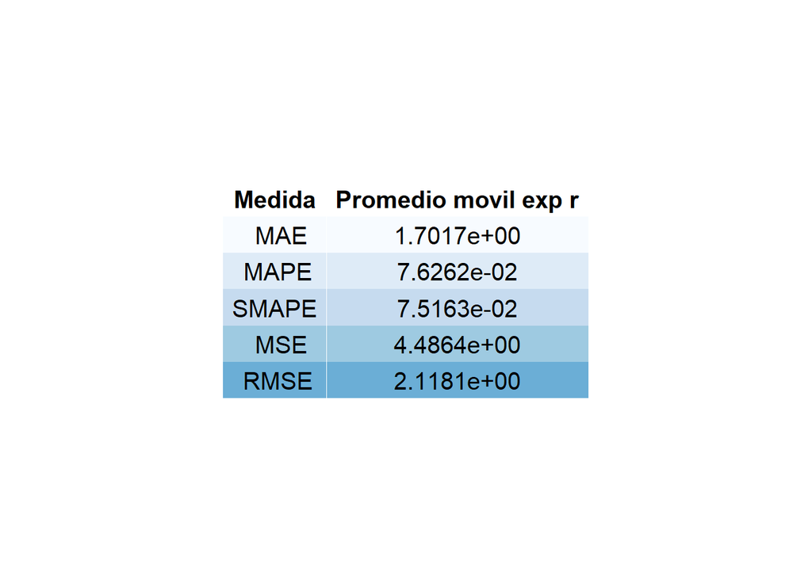

```r
r <- movavg(tsTemp, 10, type = "r")

mae_PromR<-MAE(tsTemp, r)
mape_PromR<-MAPE(tsTemp, r)
smape_PromR<-SMAPE(tsTemp, r)
mse_PromR<-MSE(tsTemp, r)
rmse_PromR<-RMSE(tsTemp, r)
medidas_PromR<-matrix(c(mae_PromR,mape_PromR,smape_PromR,mse_PromR,rmse_PromR))
rownames(medidas_PromR)<-c("MAE","MAPE","SMAPE","MSE","RMSE")
colnames(medidas_PromR)<-c("Ponderada")
df_medidas_PromR<-as.data.frame(medidas_PromR)
tab_medidas_PromR<-as.data.table(df_medidas_PromR,keep.rownames=TRUE, keep.colnames=FALSE)
colnames(tab_medidas_PromR)<-c("Medida","Promedio movil exp r")
ftab_medidas_PromR<-format(tab_medidas_PromR, digits=5,scientific=TRUE,big.mark=",",decimal.mark=".",small.mark=",",justify="right")
tem<-ttheme_minimal(base_colour = "black",base_size = 15,core=list(bg_params=list(fill=blues9,col=NA)))
grid.arrange(tableGrob(ftab_medidas_PromR,theme=tem))
```

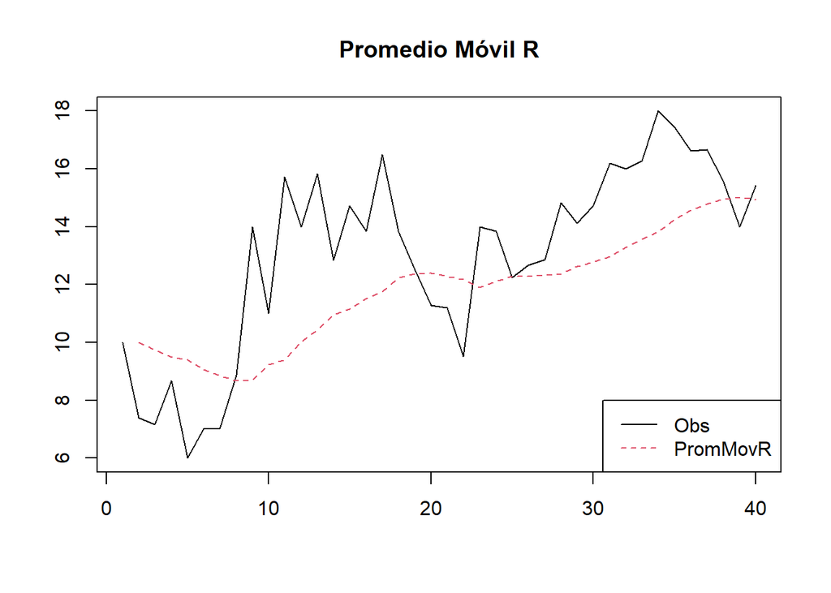

```r
fwt<-rep(0,40)
for(t in 2:40) fwt[t]<-r[t-1]
for(t in 1) fwt[t]<-NA
fw_ts<-rep(0,19)
fw_ts<-ts(fwt,start=1,frequency=1)
ts.plot(tsTemp[0:40],fw_ts,xlab=NULL,ylab=NULL, main = "Promedio Móvil R",lty=c(1:2),col=c(1,2))
legend(x="bottomright",legend=c("Obs","PromMovR"),col=c(1,2),lty=c(1,2))
```